# FEMA NRI Analysis: Midterm Project

````
#```{r}
FHLMC_tract <- FHLMC_data %>%
  rename(US_Postal_State_Code = "US.Postal.State.Code") %>%
  group_by(US_Postal_State_Code, County, Census.Tract) %>%
  summarise(n=n(),
            note_amount = sum(X.Note.amount),
            UPB_amount = sum(Acquisition.unpaid.principal.balance),
            High_DTI_note_amount = sum(X.Note.amount[Debt.to.income..DTI..ratio > 45]),
            High_DTI_UPB = sum(Acquisition.unpaid.principal.balance[Debt.to.income..DTI..ratio > 45]),
            LTV60orlower = sum(Loat.to.value.ration.at.origination.or.combined.LTV.where.available <= 60),
            LTV61_70 = sum(Loat.to.value.ration.at.origination.or.combined.LTV.where.available > 60 & Loat.to.value.ration.at.origination.or.combined.LTV.where.available <= 70),
            LTV71_80 = sum(Loat.to.value.ration.at.origination.or.combined.LTV.where.available > 70 & Loat.to.value.ration.at.origination.or.combined.LTV.where.available <= 80),
            LTV81_90 = sum(Loat.to.value.ration.at.origination.or.combined.LTV.where.available > 80 & Loat.to.value.ration.at.origination.or.combined.LTV.where.available <= 90),
            LTV91_100 = sum(Loat.to.value.ration.at.origination.or.combined.LTV.where.available > 90 & Loat.to.value.ration.at.origination.or.combined.LTV.where.available <= 100),
            LTVover100 = sum(Loat.to.value.ration.at.origination.or.combined.LTV.where.available > 100),
            DTI45orlower = sum(Debt.to.income..DTI..ratio <= 45),
            DTIover45 = sum(Debt.to.income..DTI..ratio > 45),
            DTStract = sum(X.Rural.Census.Tract == 1 | Lower.Mississippi.Delta.County == 1 | Middle.Appalachia.County == 1 | Persistent.Poverty.County == 1 | Area.of.concentrated.poverty == 1 | High.opportunity.area == 1 | Qualified.opportunity.zone.QOZ..Census.tract == 1))

view(FHLMC_tract)
write.csv(FHLMC_tract,"FHLMC_by_tract.csv")
````

```r
weather_risk <- fema %>%
  group_by(STATE) %>%
  summarise(
    FiveRisk = sum(ANYFIVERISK>0)/n()*100,
    MORTGAGE_VALUE = sum(Total_UPB),
    MORTGAGE_VALUE_hnhr = sum(Total_UPB[HIGHNEED_HIGHRISK>0]),
    HIGHDTI_UPB_value = sum(`Total High_DTI_UPB`),
    HIGHDTI_UPB_value_hnhr = sum(`Total High_DTI_UPB`[HIGHNEED_HIGHRISK>0]),
    Percent_HighDTI = sum(Total_DTIover45)/sum(MORTGAGE_COUNT)*100,
    highneedhighrisk = sum(HIGHNEED_HIGHRISK)/n()*100)
weather_risk
```

```
## # A tibble: 51 x 8
##    STATE               FiveRisk MORTGAGE_VALUE MORTGAGE_VALUE_~ HIGHDTI_UPB_val~
##    <chr>                  <dbl>          <dbl>            <dbl>            <dbl>
##  1 Alabama               36.3      18912840000        958115000       1347270000
##  2 Alaska                 0         3603400000                0        310265000
##  3 Arizona               17.5      83391760000       1953805000       7603870000
##  4 Arkansas              74.6       9756675000        898615000        653185000
##  5 California            13.1     543835010000      10542800000      69982070000
##  6 Colorado               7.05     98576615000        285215000       9314500000
##  7 Connecticut            0.121    19625445000                0       1716405000
##  8 Delaware              19.1       7646890000        271595000        682420000
##  9 District of Columb~    4.47      8878695000         75510000        640390000
## 10 Florida               35.4     121075475000       6990635000      15879075000
## # ... with 41 more rows, and 3 more variables: HIGHDTI_UPB_value_hnhr <dbl>,
## #   Percent_HighDTI <dbl>, highneedhighrisk <dbl>
```

```r
Five_Risk <- weather_risk %>%
  filter(FiveRisk>0)
Five_Risk
```

```
## # A tibble: 46 x 8
##    STATE               FiveRisk MORTGAGE_VALUE MORTGAGE_VALUE_~ HIGHDTI_UPB_val~
##    <chr>                  <dbl>          <dbl>            <dbl>            <dbl>
##  1 Alabama               36.3      18912840000        958115000       1347270000
##  2 Arizona               17.5      83391760000       1953805000       7603870000
##  3 Arkansas              74.6       9756675000        898615000        653185000
##  4 California            13.1     543835010000      10542800000      69982070000
##  5 Colorado               7.05     98576615000        285215000       9314500000
##  6 Connecticut            0.121    19625445000                0       1716405000
##  7 Delaware              19.1       7646890000        271595000        682420000
##  8 District of Columb~    4.47      8878695000         75510000        640390000
##  9 Florida               35.4     121075475000       6990635000      15879075000
## 10 Georgia               11.9      63660200000        456280000       5323490000
## # ... with 36 more rows, and 3 more variables: HIGHDTI_UPB_value_hnhr <dbl>,
## #   Percent_HighDTI <dbl>, highneedhighrisk <dbl>
```

```r
median <- Five_Risk %>%
  summarise(medFiveRisk = median(FiveRisk),
            medMORTGAGE_VALUE = median(MORTGAGE_VALUE),
            medPercent_HighDTI = median(Percent_HighDTI),
            medhighneedhighrisk = median(highneedhighrisk),
            medMORTGAGE_VALUE_hnhr = median(MORTGAGE_VALUE_hnhr),
            medHIGHDTI_UPB_value = median(HIGHDTI_UPB_value),
            medHIGHDTI_UPB_value_hnhr = median(HIGHDTI_UPB_value_hnhr)
            )
view(median)
```

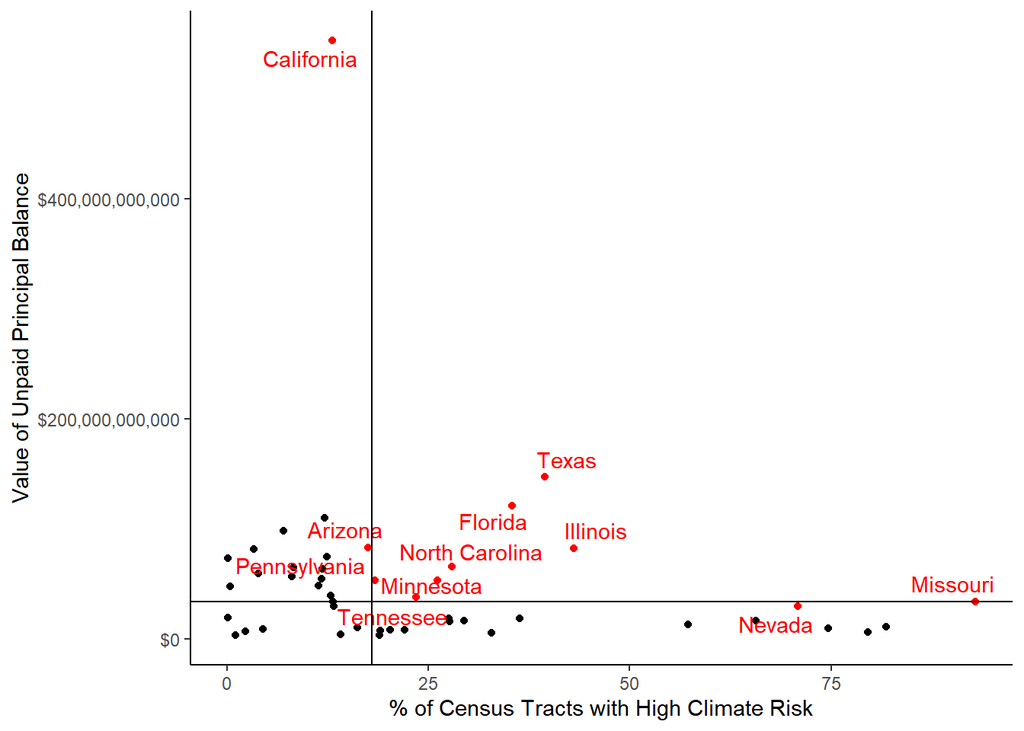

```r
Five_Risk <- weather_risk %>%
  filter(FiveRisk>0)
ggplot(data = Five_Risk, mapping = aes(x = FiveRisk, y = MORTGAGE_VALUE))+
  geom_point()+
  geom_point(data = subset(weather_risk, (FiveRisk>(median(FiveRisk)) & MORTGAGE_VALUE>median(MORTGAGE_VALUE)) | STATE == "California"), segment.color = 'grey80', colour = "red")+
  theme_classic()+
  labs(x = '% of Census Tracts with High Climate Risk', y = 'Value of Unpaid Principal Balance')+
  geom_text_repel(data = subset(weather_risk, (FiveRisk>(median(FiveRisk)) & MORTGAGE_VALUE>median(MORTGAGE_VALUE)) | STATE == "California"), aes(label = STATE), segment.color = 'grey80', colour = "red")+
  geom_vline(data = median, mapping = aes(xintercept = medFiveRisk))+
  geom_hline(data = median, mapping = aes(yintercept = medMORTGAGE_VALUE))+
  scale_y_continuous(labels=scales::dollar_format())
```

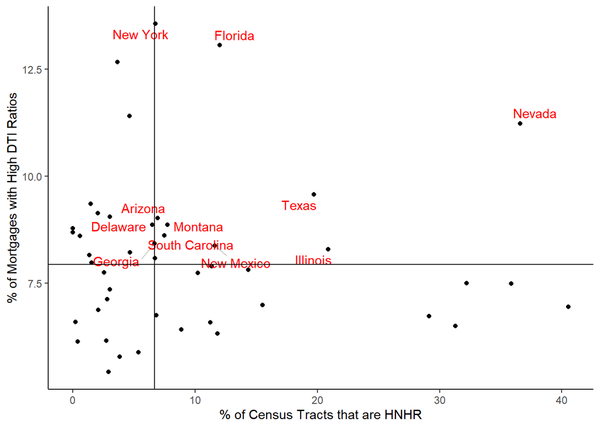

```r
Five_Risk <- weather_risk %>%
  filter(FiveRisk>0)
ggplot(data = Five_Risk, mapping = aes(x = highneedhighrisk, y = Percent_HighDTI))+
  geom_point()+
  theme_classic()+
  labs(x = '% of Census Tracts that are HNHR', y = '% of Mortgages with High DTI Ratios')+
  geom_text_repel(data = subset(weather_risk, (highneedhighrisk>(median(highneedhighrisk)) & Percent_HighDTI>median(Percent_HighDTI))), aes(label = STATE), segment.color = 'grey80', colour = "red")+
  geom_vline(data = median, mapping = aes(xintercept = medhighneedhighrisk))+
  geom_hline(data = median, mapping = aes(yintercept = medPercent_HighDTI))
```

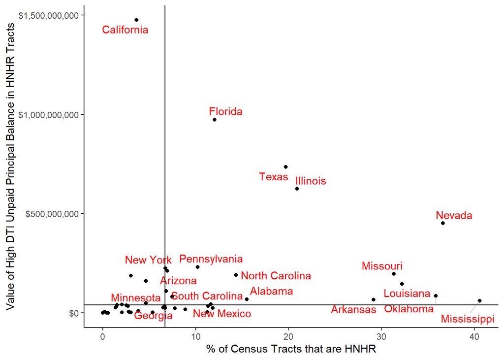

```r
Five_Risk <- weather_risk %>%
  filter(FiveRisk>0)
ggplot(data = Five_Risk, mapping = aes(x = highneedhighrisk, y = HIGHDTI_UPB_value_hnhr))+
  geom_point()+
  theme_classic()+
  labs(x = '% of Census Tracts that are HNHR', y = 'Value of High DTI Unpaid Principal Balance in HNHR Tracts')+
  geom_text_repel(data = subset(weather_risk, (highneedhighrisk>(median(highneedhighrisk)) & HIGHDTI_UPB_value_hnhr>median(HIGHDTI_UPB_value_hnhr)) | STATE == "California"), aes(label = STATE), segment.color = 'grey80', colour = "red")+
  geom_vline(data = median, mapping = aes(xintercept = medhighneedhighrisk))+
  geom_hline(data = median, mapping = aes(yintercept = medHIGHDTI_UPB_value_hnhr))+
  scale_y_continuous(labels=scales::dollar_format())
```

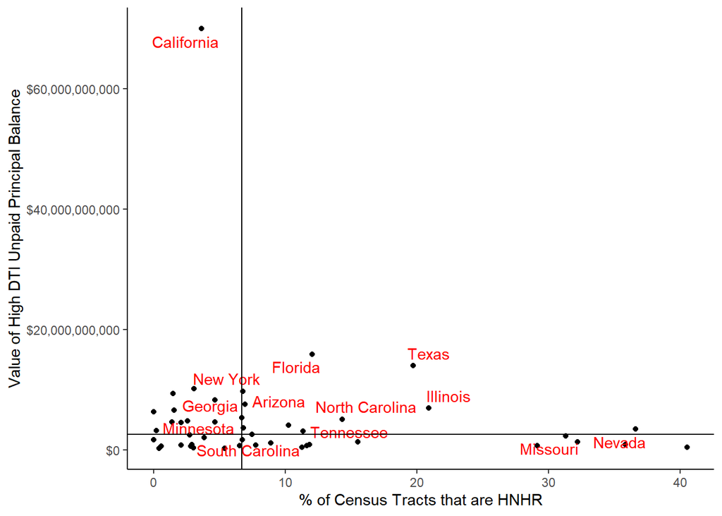

```r
Five_Risk <- weather_risk %>%
  filter(FiveRisk>0)
ggplot(data = Five_Risk, mapping = aes(x = highneedhighrisk, y = HIGHDTI_UPB_value))+
  geom_point()+
  theme_classic()+
  labs(x = '% of Census Tracts that are HNHR', y = 'Value of High DTI Unpaid Principal Balance')+
  geom_text_repel(data = subset(weather_risk, (highneedhighrisk>(median(highneedhighrisk)) & HIGHDTI_UPB_value>median(HIGHDTI_UPB_value)) | STATE == "California"), aes(label = STATE), segment.color = 'grey80', colour = "red")+
  geom_vline(data = median, mapping = aes(xintercept = medhighneedhighrisk))+
  geom_hline(data = median, mapping = aes(yintercept = medHIGHDTI_UPB_value))+
  scale_y_continuous(labels=scales::dollar_format())
```

```r
weather_risk_florida <- fema %>%
  filter(STATE=="Florida") %>%
  group_by(COUNTY) %>%
  summarise(
    FiveRisk = sum(ANYFIVERISK>0)/n()*100,
    MORTGAGE_VALUE = sum(Total_UPB),
    MORTGAGE_VALUE_hnhr = sum(Total_UPB[HIGHNEED_HIGHRISK>0]),
    HIGHDTI_UPB_value = sum(`Total High_DTI_UPB`),
    HIGHDTI_UPB_value_hnhr = sum(`Total High_DTI_UPB`[HIGHNEED_HIGHRISK>0]),
    Percent_HighDTI = sum(Total_DTIover45)/sum(MORTGAGE_COUNT)*100,
    highneedhighrisk = sum(HIGHNEED_HIGHRISK)/n()*100)
weather_risk_florida
```

```
## # A tibble: 67 x 8
##    COUNTY    FiveRisk MORTGAGE_VALUE MORTGAGE_VALUE_hnhr HIGHDTI_UPB_value
##    <chr>        <dbl>          <dbl>               <dbl>             <dbl>
##  1 Alachua      58.9      1040700000            41345000          91250000
##  2 Baker       100          60920000                   0           3265000
##  3 Bay          95.3       870515000            40260000         122200000
##  4 Bradford     50          28200000                   0           3210000
##  5 Brevard      46.0      3603140000           317045000         409360000
##  6 Broward       7.48    11873650000           102830000        1830300000
##  7 Calhoun     100           8950000                   0            815000
##  8 Charlotte    97.4      1288995000            56100000         207670000
##  9 Citrus       96.3       506215000            26455000          54940000
## 10 Clay         50         751655000            48375000          74160000
## # ... with 57 more rows, and 3 more variables: HIGHDTI_UPB_value_hnhr <dbl>,
## #   Percent_HighDTI <dbl>, highneedhighrisk <dbl>
```

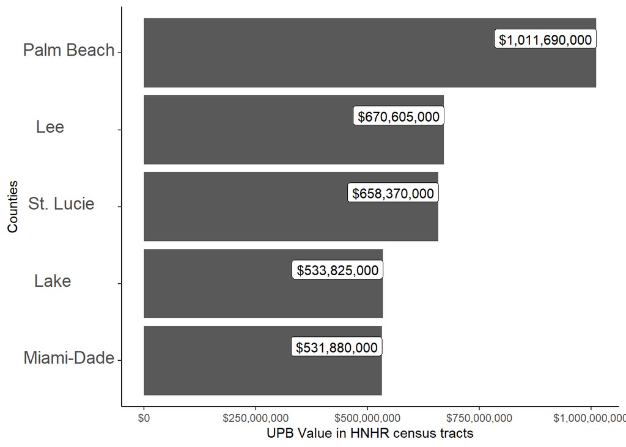

```r
topHNHRvalue <- weather_risk_florida %>%
  filter(MORTGAGE_VALUE_hnhr>500000000)
ggplot(data = topHNHRvalue, mapping = aes(x= MORTGAGE_VALUE_hnhr, y= fct_reorder(COUNTY,MORTGAGE_VALUE_hnhr)))+
  geom_col() +
  theme_classic()+
  theme(axis.text.y = element_text(size=14, vjust = 0.2, hjust=0.2))+
  labs(
    x= "UPB Value in HNHR census tracts",
    y= "Counties")+
  geom_label(aes(label=scales::dollar(MORTGAGE_VALUE_hnhr)), position=position_dodge(width=0.9), hjust=1, vjust=-0.25)+
  guides(color=FALSE)+
  scale_x_continuous(labels=scales::dollar_format())
```

```r
Florida_median <- weather_risk_florida %>%
  summarise(medFiveRisk = median(FiveRisk),
            medMORTGAGE_VALUE = median(MORTGAGE_VALUE),
            medPercent_HighDTI = median(Percent_HighDTI),
            medhighneedhighrisk = median(highneedhighrisk),
            medMORTGAGE_VALUE_hnhr = median(MORTGAGE_VALUE_hnhr),
            medHIGHDTI_UPB_value = median(HIGHDTI_UPB_value),
            medHIGHDTI_UPB_value_hnhr = median(HIGHDTI_UPB_value_hnhr)
            )
view(Florida_median)
```

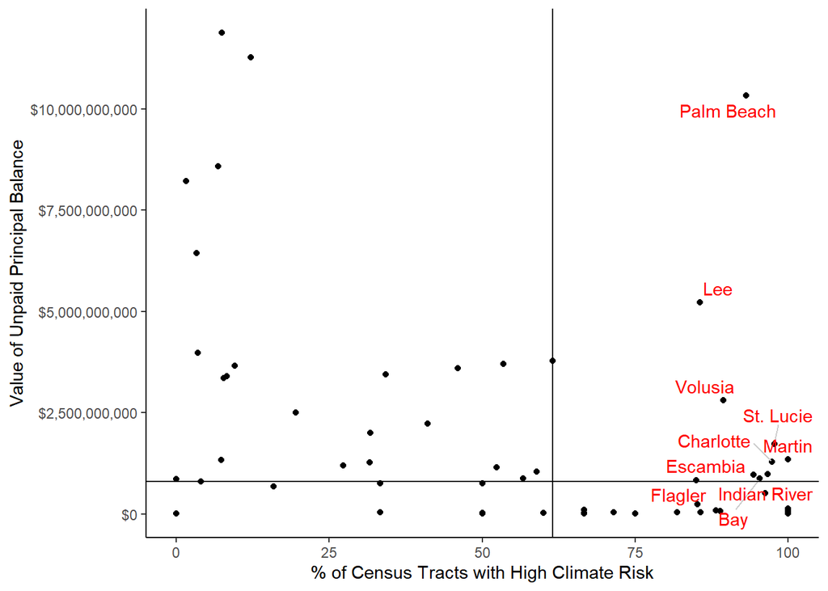

```r
ggplot(data = weather_risk_florida, mapping = aes(x = FiveRisk, y = MORTGAGE_VALUE))+
  geom_point()+
  theme_classic()+
  labs(x = '% of Census Tracts with High Climate Risk', y = 'Value of Unpaid Principal Balance')+
  geom_text_repel(data = subset(weather_risk_florida, (FiveRisk>(median(FiveRisk)) & MORTGAGE_VALUE>median(MORTGAGE_VALUE))), aes(label = COUNTY), segment.color = 'grey80', colour = "red")+
  geom_vline(data = Florida_median, mapping = aes(xintercept = medFiveRisk))+
  geom_hline(data = Florida_median, mapping = aes(yintercept = medMORTGAGE_VALUE))+
  scale_y_continuous(labels=scales::dollar_format())
```

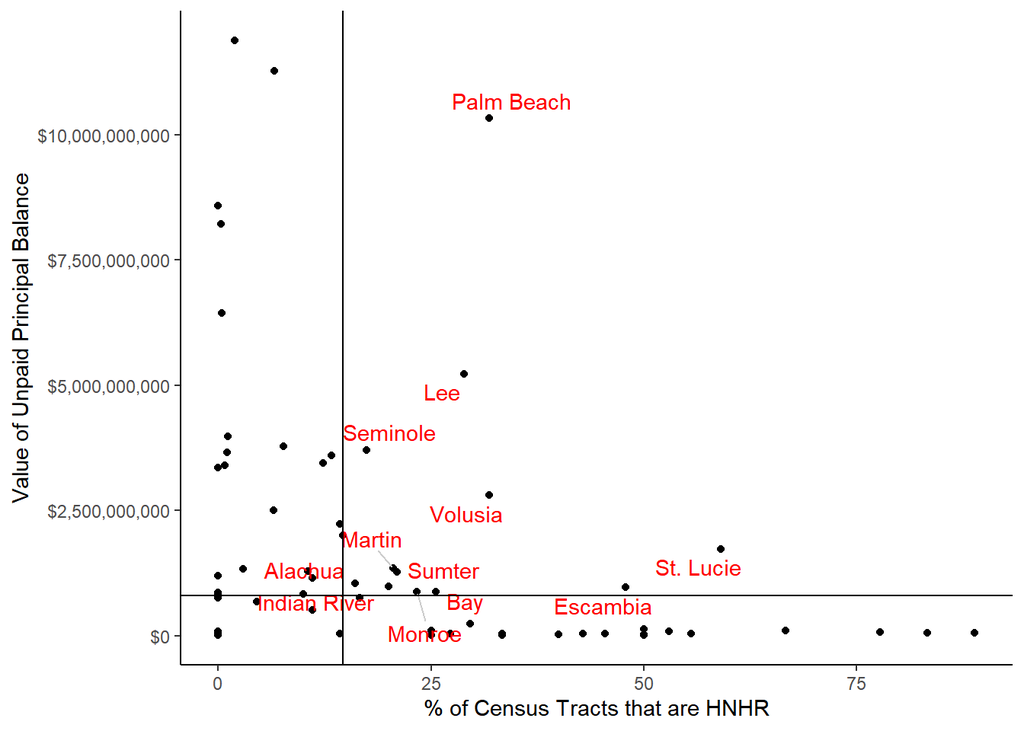

```r
ggplot(data = weather_risk_florida, mapping = aes(highneedhighrisk, y = MORTGAGE_VALUE))+
  geom_point()+
  theme_classic()+
  labs(x = '% of Census Tracts that are HNHR', y = 'Value of Unpaid Principal Balance')+
  geom_text_repel(data = subset(weather_risk_florida, (highneedhighrisk>(median(highneedhighrisk)) & MORTGAGE_VALUE>median(MORTGAGE_VALUE))), aes(label = COUNTY), segment.color = 'grey80', colour = "red")+
  geom_vline(data = Florida_median, mapping = aes(xintercept = medhighneedhighrisk))+
  geom_hline(data = Florida_median, mapping = aes(yintercept = medMORTGAGE_VALUE))+
  scale_y_continuous(labels=scales::dollar_format())
```

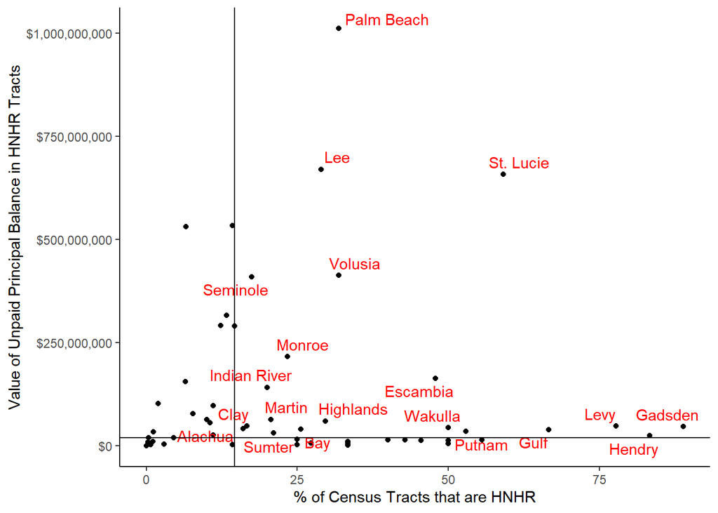

```r
ggplot(data = weather_risk_florida, mapping = aes(x = highneedhighrisk, y = MORTGAGE_VALUE_hnhr))+
  geom_point()+
  theme_classic()+
  labs(x = '% of Census Tracts that are HNHR', y = 'Value of Unpaid Principal Balance in HNHR Tracts')+
  geom_text_repel(data = subset(weather_risk_florida, (highneedhighrisk>(median(highneedhighrisk)) & MORTGAGE_VALUE_hnhr>median(MORTGAGE_VALUE_hnhr))), aes(label = COUNTY), segment.color = 'grey80', colour = "red")+
  geom_vline(data = Florida_median, mapping = aes(xintercept = medhighneedhighrisk))+
  geom_hline(data = Florida_median, mapping = aes(yintercept = medMORTGAGE_VALUE_hnhr))+
  scale_y_continuous(labels=scales::dollar_format())
```

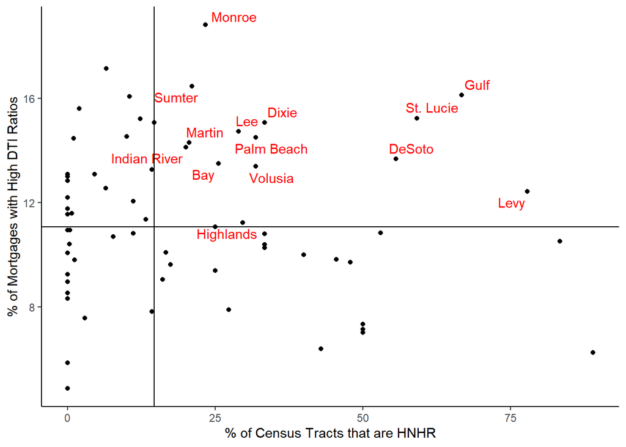

```r
ggplot(data = weather_risk_florida, mapping = aes(x = highneedhighrisk, y = Percent_HighDTI))+
  geom_point()+
  theme_classic()+
  labs(x = '% of Census Tracts that are HNHR', y = '% of Mortgages with High DTI Ratios')+
  geom_text_repel(data = subset(weather_risk_florida, (highneedhighrisk>(median(highneedhighrisk)) & Percent_HighDTI>median(Percent_HighDTI))), aes(label = COUNTY), segment.color = 'grey80', colour = "red")+
  geom_vline(data = Florida_median, mapping = aes(xintercept = medhighneedhighrisk))+
  geom_hline(data = Florida_median, mapping = aes(yintercept = medPercent_HighDTI))
```

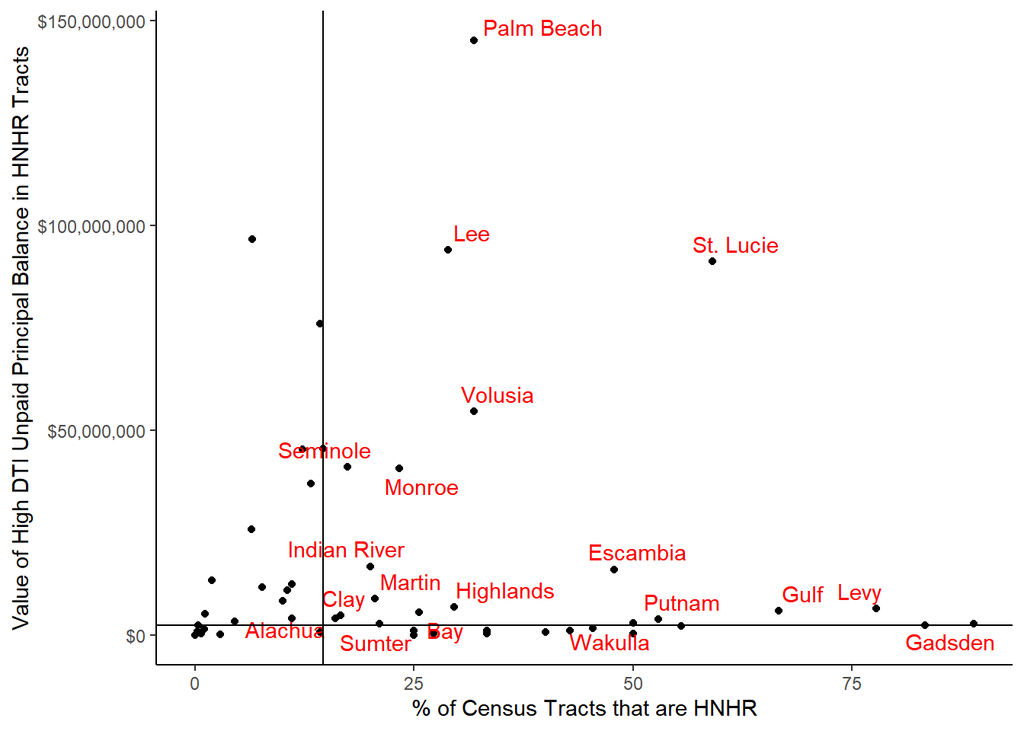

```r
ggplot(data = weather_risk_florida, mapping = aes(x = highneedhighrisk, y = HIGHDTI_UPB_value_hnhr))+
  geom_point()+
  theme_classic()+
  labs(x = '% of Census Tracts that are HNHR', y = 'Value of High DTI Unpaid Principal Balance in HNHR Tracts')+
  geom_text_repel(data = subset(weather_risk_florida, (highneedhighrisk>(median(highneedhighrisk)) & HIGHDTI_UPB_value_hnhr>median(HIGHDTI_UPB_value_hnhr))), aes(label = COUNTY), segment.color = 'grey80', colour = "red")+
  geom_vline(data = Florida_median, mapping = aes(xintercept = medhighneedhighrisk))+
  geom_hline(data = Florida_median, mapping = aes(yintercept = medHIGHDTI_UPB_value_hnhr))+
  scale_y_continuous(labels=scales::dollar_format())
```

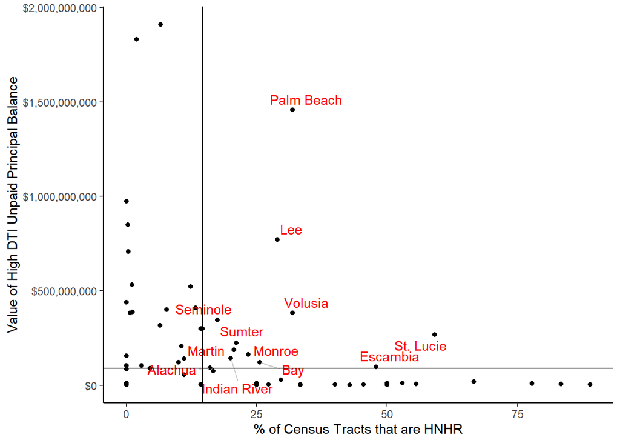

```r
ggplot(data = weather_risk_florida, mapping = aes(x = highneedhighrisk, y = HIGHDTI_UPB_value))+
  geom_point()+
  theme_classic()+
  labs(x = '% of Census Tracts that are HNHR', y = 'Value of High DTI Unpaid Principal Balance')+
  geom_text_repel(data = subset(weather_risk_florida, (highneedhighrisk>(median(highneedhighrisk)) & HIGHDTI_UPB_value>median(HIGHDTI_UPB_value))), aes(label = COUNTY), segment.color = 'grey80', colour = "red")+
  geom_vline(data = Florida_median, mapping = aes(xintercept = medhighneedhighrisk))+
  geom_hline(data = Florida_median, mapping = aes(yintercept = medHIGHDTI_UPB_value))+
  scale_y_continuous(labels=scales::dollar_format())
```

```r
weather_risk_california <- fema %>%
  filter(STATE=="California") %>%
  group_by(COUNTY) %>%
  summarise(
    FiveRisk = sum(ANYFIVERISK>0)/n()*100,
    MORTGAGE_VALUE = sum(Total_UPB),
    MORTGAGE_VALUE_hnhr = sum(Total_UPB[HIGHNEED_HIGHRISK>0]),
    HIGHDTI_UPB_value = sum(`Total High_DTI_UPB`),
    HIGHDTI_UPB_value_hnhr = sum(`Total High_DTI_UPB`[HIGHNEED_HIGHRISK>0]),
    Percent_HighDTI = sum(Total_DTIover45)/sum(MORTGAGE_COUNT)*100,
    highneedhighrisk = sum(HIGHNEED_HIGHRISK)/n()*100)

weather_risk_california
```

```
## # A tibble: 58 x 8
##    COUNTY       FiveRisk MORTGAGE_VALUE MORTGAGE_VALUE_hnhr HIGHDTI_UPB_value
##    <chr>           <dbl>          <dbl>               <dbl>             <dbl>
##  1 Alameda          2.22    33342220000                   0        3422555000
##  2 Alpine         100          29210000                   0           3320000
##  3 Amador         100         468640000            93715000          49105000
##  4 Butte           49.0      1839950000            92040000         186515000
##  5 Calaveras      100         756510000            60585000          86215000
##  6 Colusa         100         108385000            51885000          14265000
##  7 Contra Costa     9.66    25949890000          1033315000        2813955000
##  8 Del Norte       14.3        93880000                   0          11320000
##  9 El Dorado       50        4521505000           127625000         475450000
## 10 Fresno          10.1      6511670000            55440000         667125000
## # ... with 48 more rows, and 3 more variables: HIGHDTI_UPB_value_hnhr <dbl>,
## #   Percent_HighDTI <dbl>, highneedhighrisk <dbl>
```

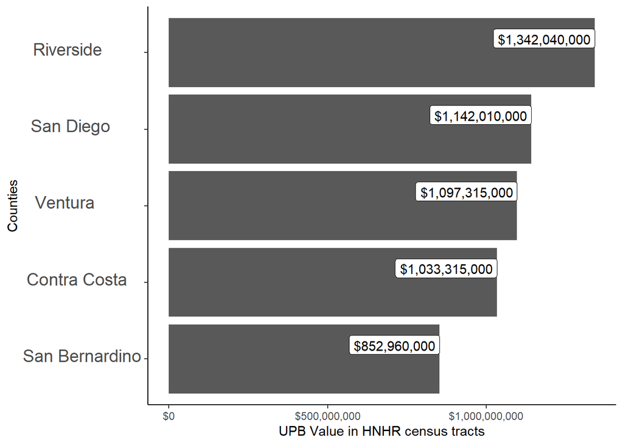

```r
topHNHRvalue <- weather_risk_california %>%
  filter(MORTGAGE_VALUE_hnhr>500000000)
ggplot(data = topHNHRvalue, mapping = aes(x= MORTGAGE_VALUE_hnhr, y= fct_reorder(COUNTY,MORTGAGE_VALUE_hnhr)))+
  geom_col() +
  theme_classic()+
  theme(axis.text.y = element_text(size=14, vjust = 0.2, hjust=0.2))+
  labs(
    x= "UPB Value in HNHR census tracts",
    y= "Counties")+
  geom_label(aes(label=scales::dollar(MORTGAGE_VALUE_hnhr)), position=position_dodge(width=0.9), hjust=1, vjust=-0.25)+
  guides(color=FALSE)+
  scale_x_continuous(labels=scales::dollar_format())
```

```r
California_median <- weather_risk_california %>%
  summarise(medFiveRisk = median(FiveRisk),
            medMORTGAGE_VALUE = median(MORTGAGE_VALUE),
            medPercent_HighDTI = median(Percent_HighDTI),
            medhighneedhighrisk = median(highneedhighrisk),
            medMORTGAGE_VALUE_hnhr = median(MORTGAGE_VALUE_hnhr),
            medHIGHDTI_UPB_value = median(HIGHDTI_UPB_value),
            medHIGHDTI_UPB_value_hnhr = median(HIGHDTI_UPB_value_hnhr)
            )
view(California_median)
```

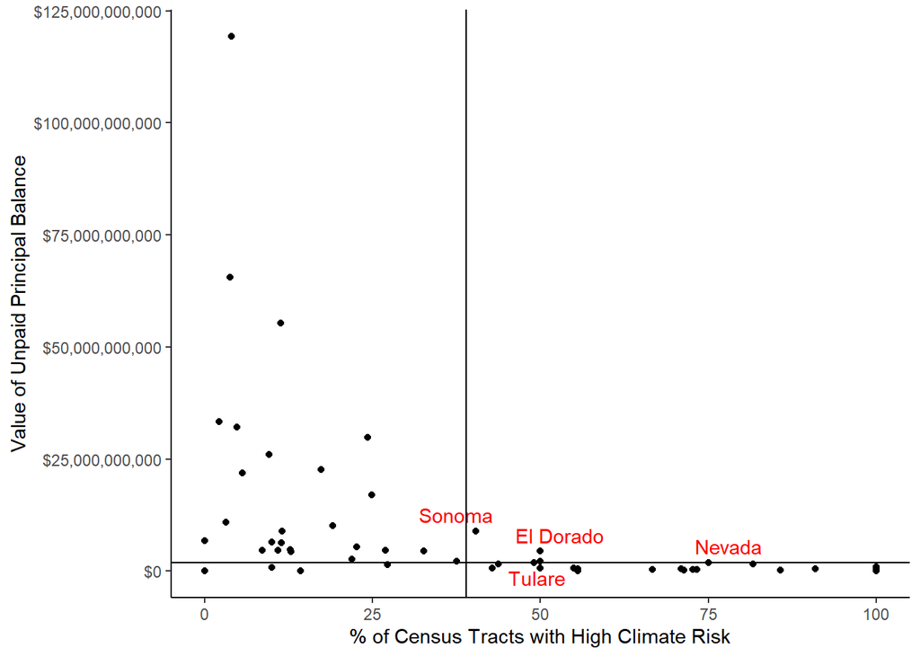

```r
ggplot(data = weather_risk_california, mapping = aes(x = FiveRisk, y = MORTGAGE_VALUE))+
  geom_point()+
  theme_classic()+
  labs(x = '% of Census Tracts with High Climate Risk', y = 'Value of Unpaid Principal Balance')+
  geom_text_repel(data = subset(weather_risk_california, (FiveRisk>(median(FiveRisk)) & MORTGAGE_VALUE>median(MORTGAGE_VALUE))), aes(label = COUNTY), segment.color = 'grey80', colour = "red")+
  geom_vline(data = California_median, mapping = aes(xintercept = medFiveRisk))+
  geom_hline(data = California_median, mapping = aes(yintercept = medMORTGAGE_VALUE))+
  scale_y_continuous(labels=scales::dollar_format())
```

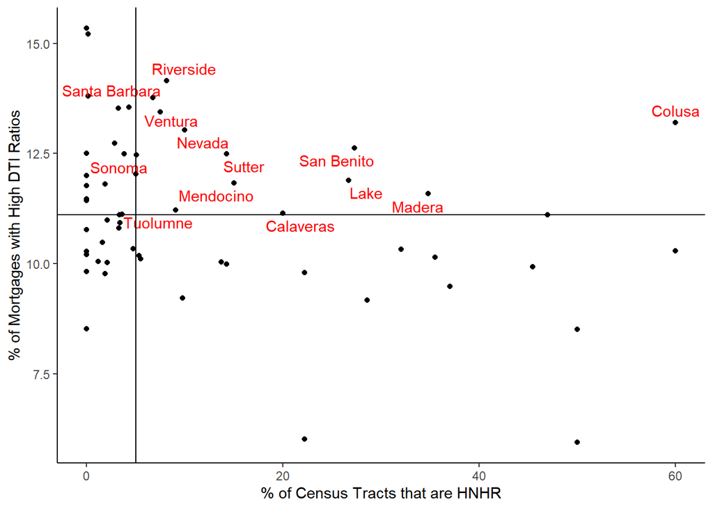

```r
ggplot(data = weather_risk_california, mapping = aes(x = highneedhighrisk, y = Percent_HighDTI))+
  geom_point()+
  theme_classic()+
  labs(x = '% of Census Tracts that are HNHR', y = '% of Mortgages with High DTI Ratios')+
  geom_text_repel(data = subset(weather_risk_california, (highneedhighrisk>(median(highneedhighrisk)) & Percent_HighDTI>median(Percent_HighDTI))), aes(label = COUNTY), segment.color = 'grey80', colour = "red")+
  geom_vline(data = California_median, mapping = aes(xintercept = medhighneedhighrisk))+
  geom_hline(data = California_median, mapping = aes(yintercept = medPercent_HighDTI))
```

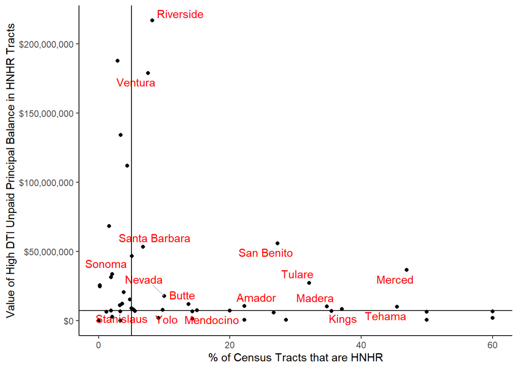

```r
ggplot(data = weather_risk_california, mapping = aes(x = highneedhighrisk, y = HIGHDTI_UPB_value_hnhr))+
  geom_point()+
  theme_classic()+
  labs(x = '% of Census Tracts that are HNHR', y = 'Value of High DTI Unpaid Principal Balance in HNHR Tracts')+
  geom_text_repel(data = subset(weather_risk_california, (highneedhighrisk>(median(highneedhighrisk)) & HIGHDTI_UPB_value_hnhr>median(HIGHDTI_UPB_value_hnhr))), aes(label = COUNTY), segment.color = 'grey80', colour = "red")+
  geom_vline(data = California_median, mapping = aes(xintercept = medhighneedhighrisk))+
  geom_hline(data = California_median, mapping = aes(yintercept = medHIGHDTI_UPB_value_hnhr))+
  scale_y_continuous(labels=scales::dollar_format())
```

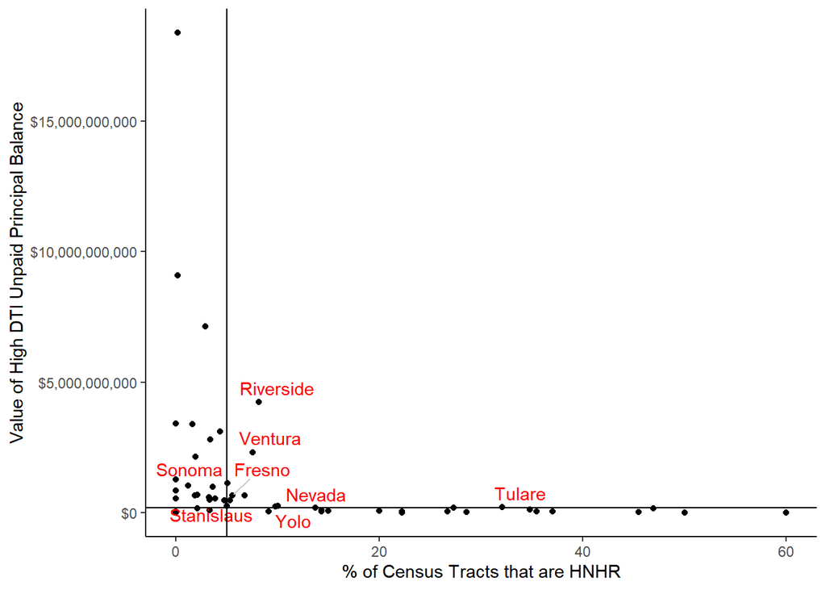

```r
ggplot(data = weather_risk_california, mapping = aes(x = highneedhighrisk, y = HIGHDTI_UPB_value))+
  geom_point()+
  theme_classic()+
  labs(x = '% of Census Tracts that are HNHR', y = 'Value of High DTI Unpaid Principal Balance')+
  geom_text_repel(data = subset(weather_risk_california, (highneedhighrisk>(median(highneedhighrisk)) & HIGHDTI_UPB_value>median(HIGHDTI_UPB_value))), aes(label = COUNTY), segment.color = 'grey80', colour = "red")+
  geom_vline(data = California_median, mapping = aes(xintercept = medhighneedhighrisk))+
  geom_hline(data = California_median, mapping = aes(yintercept = medHIGHDTI_UPB_value))+
  scale_y_continuous(labels=scales::dollar_format())
```